# Homework 2 Solutions

Gianni Spiga

2022-10-13

## Question 1

```r
# Load in data
display <- read.csv("~/GitHub/BAX-441-FQ-2022/Homework/HW2/Display Space.csv")
head(display, 15)
```

```
##     Sales Display.Feet
## 1   29.00            1
## 2  358.41            6
## 3  382.30            7
## 4  279.90            4
## 5  400.40            6
## 6  398.30            7
## 7  279.90            5
## 8  204.90            2
## 9  284.80            5
## 10 357.80            7
## 11 256.70            5
## 12  25.30            1
## 13 220.40            2
## 14  41.90            1
## 15 281.20            7
```

a.)

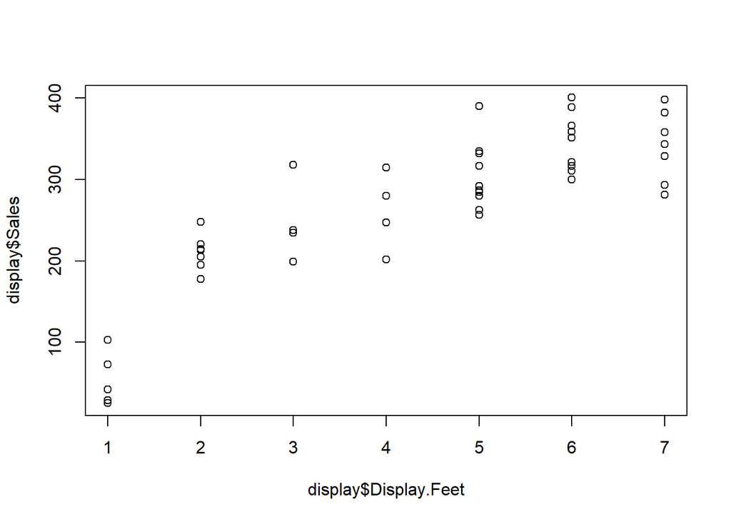

```r
library(ggplot2)
library(plotly)
# We create a scatter plot
plot(display$Display.Feet, display$Sales)
```

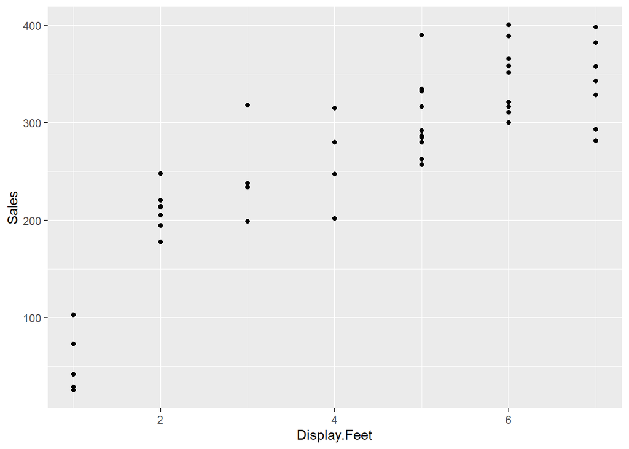

```r
ggplot(data = display, aes(x = Display.Feet, y = Sales)) + geom_point()
```

We can see from the scatter plots above that the relationship seems to be slightly nonlinear, the difference in sales for each unit increase of Display Feet is high in the beginning but begins to plateau at the end of the plot. We would expect this relationship to be linear, i.e. each increase in display feet should result in a constant increase in sales.

b.)

```r
# Build a model
display.Model <- lm(Sales ~ Display.Feet, data = display)

summary(display.Model) # $coefficients
```

```
##
## Call:
## lm(formula = Sales ~ Display.Feet, data = display)
##
## Residuals:
##      Min       1Q   Median       3Q      Max
## -107.489  -29.552    0.085   33.342  105.598
##
## Coefficients:
##              Estimate Std. Error t value Pr(>|t|)
## (Intercept)     93.03      18.23   5.104 6.50e-06 ***
## Display.Feet    39.76       3.77  10.547 9.55e-14 ***
## ---
## Signif. codes:  0 '***' 0.001 '**' 0.01 '*' 0.05 '.' 0.1 ' ' 1
##
## Residual standard error: 51.59 on 45 degrees of freedom
## Multiple R-squared:  0.712,  Adjusted R-squared:  0.7056
## F-statistic: 111.2 on 1 and 45 DF,  p-value: 9.555e-14
```

From the model, we can see that a change in Display feet results in a predicted 39.76 dollar increase in sales. If we were to not dedicate any space for a display (Display Feet = 0), we would expect product sales to be 93.03 dollars.

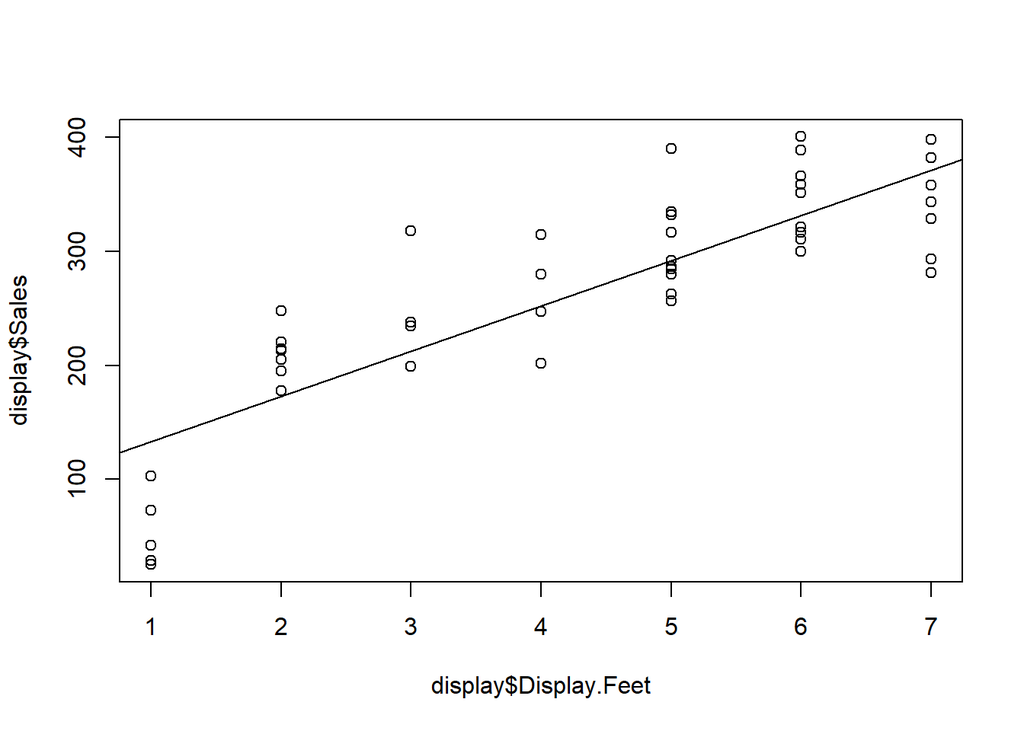

```r
plot(display$Display.Feet, display$Sales)
abline(display.Model)
```

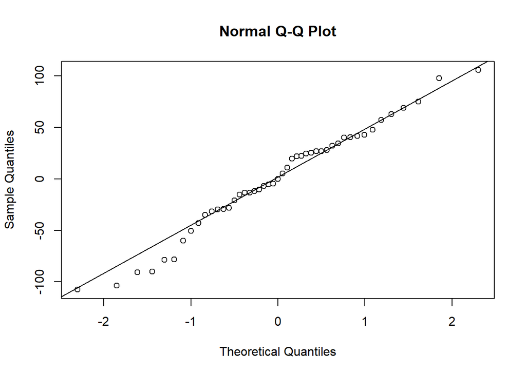

```r
#Lets look at residuals as well
qqnorm(display.Model$residuals)
qqline(display.Model$residuals)
```

When we look at our fitted line on our data, we find that our predicted line does not capture any of the data when our display feet is 1 or 2. Howevever, as dIsplay feet gets larger than 2, the line begins to travel through more of the points in our data. The nonlinear relationship in this data is hurting our prediction accuracy.

c.)

```r
# Let's look for an optimal transformation using BoxCox technique
library(MASS)
```

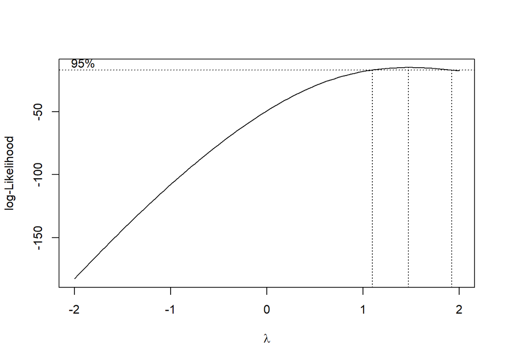

```r
boxcox(display$Sales ~ display$Display.Feet)
```